[GitHub](https://github.com/Janssena/DeepCompartmentModels.jl)[](https://github.com/Janssena/DeepCompartmentModels.jl/blob/main/tutorials/05-loading-data.qmd)

# Loading data and dosing events

*From NONMEM-style tables to Individuals and Populations*

Everything in the package operates on a `Population` of `Individual`s. An individual holds four things:

| field | meaning |
| --- | --- |
| `id` | an integer or string label |
| `x` | the covariates, a vector (static over time) |
| `t`, `y` | observation times and observed values |
| `callback` | the *dosing events*, an ODE-solver callback |

The first three are plain arrays. The interesting one is the callback, so this tutorial starts there and then builds populations from the two datasets in the repository's `data/` folder, which have very different dosing designs.

```julia
using DeepCompartmentModels
using DataFrames, CSV
using CairoMakie

datadir = joinpath(pkgdir(DeepCompartmentModels), "data")
```

## Dosing callbacks

Drug enters the ODE system as an *infusion rate* `I`, which is the last element of the parameter vector the ODE function receives (this is why the built-in ODEs unpack `..., I = p`). A dose of `amt` given over `duration` is the rate `amt / duration` during the infusion and `0` otherwise. `generate_dosing_callback` turns a table of dosing events into a callback that switches that rate on and off at the right times.

Each row of the table is one dose. With two columns, `[time amount]`, every dose is a bolus, modelled as a very short infusion (by default one minute, with times in hours). With four columns, `[time amount rate duration]`, the infusion is given explicitly.

```julia
bolus = generate_dosing_callback([0.0 100.0])
infusion = generate_dosing_callback([0.0 100.0 50.0 2.0])      # 100 mg at 50 mg/h for 2 h
repeated = generate_dosing_callback([0.0 100.0; 12.0 100.0; 24.0 100.0])   # three boluses
```

To see what a callback does we can solve a one-compartment model for a given individual. `solve(model, individual, z)` takes the ODE parameters `z` (here `[CL, V]`):

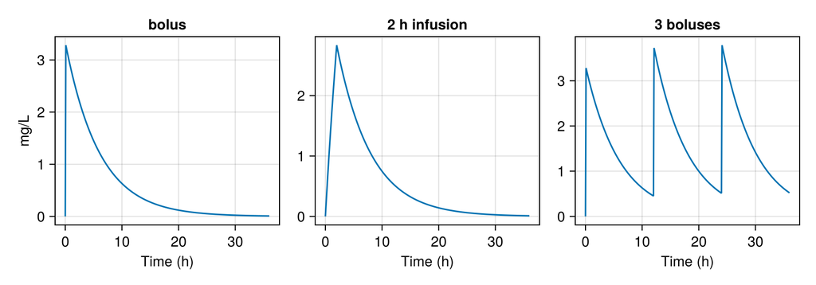

```julia
model = DCM(one_comp!, 1, Lux.Dense(1 => 2))   # the network is not used when we pass z ourselves
z = Float32[5, 30]                              # CL = 5 L/h, V = 30 L
grid = Float32.(0:0.1:36)

fig = Figure(size = (800, 280))
for (j, (name, cb)) in enumerate(["bolus" => bolus, "2 h infusion" => infusion, "3 boluses" => repeated])
    indv = Individual(1, [70f0], grid, zeros(Float32, length(grid)), cb)
    sol = solve(model, indv, z; saveat = grid, dt = 0.01f0)
    ax = Axis(fig[1, j]; title = name, xlabel = "Time (h)", ylabel = j == 1 ? "mg/L" : "")
    lines!(ax, grid, Array(sol)[1, :])
end
fig
```

A few more options:

- `generate_dosing_callback(A, T)` creates the callback in number type `T` (the default is `Float32`). An `Individual` warns if its callback and data types differ.
- `S1` scales all doses, for example to convert mg into the unit of the ODE state.
- `bolus_duration` sets the length of the pseudo-infusion used for boluses.

```julia
generate_dosing_callback([0.0 100.0]; S1 = 1 / 1000)   # doses in mg, state in g
```

## One bolus per subject: warfarin

The warfarin dataset has the usual NONMEM columns. Dose rows have `MDV = 1`, observation rows `MDV = 0`, and `DVID` tells the two measured responses apart (1 is the plasma concentration, 2 a pharmacodynamic effect). We only use the concentrations here.

```julia
warfarin = DataFrame(CSV.File(joinpath(datadir, "warfarin.csv")))
select(first(warfarin, 3), :ID, :TIME, :WEIGHT, :AGE, :SEX, :DOSE, :RATE, :DURATION, :DV, :MDV)
```

3×10 DataFrame

| Row | ID Int64 | TIME Float64 | WEIGHT Float64 | AGE Int64 | SEX Int64 | DOSE Float64? | RATE Float64? | DURATION Float64? | DV Float64? | MDV Int64 |
| --- | --- | --- | --- | --- | --- | --- | --- | --- | --- | --- |
| 1 | 10 | 0.0 | 66.7 | 50 | 1 | 100.0 | 12000.0 | 0.00833333 | missing | 1 |
| 2 | 10 | 0.5 | 66.7 | 50 | 1 | missing | missing | missing | 0.0 | 0 |
| 3 | 10 | 1.0 | 66.7 | 50 | 1 | missing | missing | missing | 1.9 | 0 |

One individual is one `ID` group. The dose matrix comes from the rows with `MDV == 1` and the observations from the rows with `MDV == 0`:

```julia
function warfarin_individual(g)
    covariates = Float32[g.WEIGHT[1], g.AGE[1], g.SEX[1]]
    doses = Matrix{Float32}(g[g.MDV .== 1, [:TIME, :DOSE, :RATE, :DURATION]])
    obs = g[g.MDV .== 0, :]
    return Individual(g.ID[1], covariates, obs.TIME, obs.DV, generate_dosing_callback(doses))
end

pk = warfarin[warfarin.DVID .== 1, :]
warfarin_pop = Population([warfarin_individual(g) for g in groupby(pk, :ID)])
length(warfarin_pop), get_x(warfarin_pop)[:, 1:3]
```

```
(32, Float32[66.7 66.7 80.0; 50.0 31.0 40.0; 1.0 1.0 1.0])
```

`get_x(population)` stacks the covariates into a matrix with one column per individual, which is what the network receives. `get_t` and `get_y` return vectors with the times and observations of each individual.

## Many infusions per subject: tobramycin

In the tobramycin data every dose is an `EVID = 1` row, patients receive dozens of doses, and there is no rate column. We assume 30-minute infusions, which is common for this drug; a dataset with a `RATE` or `DURATION` column would use those instead.

```julia
tobramycin = DataFrame(CSV.File(joinpath(datadir, "tobramycin.csv")))
select(tobramycin[tobramycin.ID .== 1, :][[1, 2, 3, 34, 35], :], :ID, :TIME, :CP, :EVID, :DOSE, :WT, :AGE, :SEX, :CLCR)
```

5×9 DataFrame

| Row | ID Int64 | TIME Float64 | CP Float64 | EVID Int64 | DOSE Int64 | WT Float64 | AGE Int64 | SEX Int64 | CLCR Float64 |
| --- | --- | --- | --- | --- | --- | --- | --- | --- | --- |
| 1 | 1 | 0.0 | 0.0 | 1 | 100 | 58.4 | 71 | 1 | 58.0 |
| 2 | 1 | 8.0 | 0.0 | 1 | 80 | 58.4 | 71 | 1 | 58.0 |
| 3 | 1 | 16.0 | 0.0 | 1 | 80 | 58.4 | 71 | 1 | 58.0 |
| 4 | 1 | 248.0 | 0.0 | 1 | 120 | 58.4 | 71 | 1 | 58.0 |
| 5 | 1 | 256.0 | 0.0 | 1 | 120 | 58.4 | 71 | 1 | 58.0 |

```julia
function tobramycin_individual(g; infusion_hours = 0.5f0)
    dose_rows = g[g.EVID .== 1, :]
    doses = Float32[dose_rows.TIME dose_rows.DOSE dose_rows.DOSE ./ infusion_hours fill(infusion_hours, nrow(dose_rows))]
    obs = g[g.EVID .== 0, :]
    covariates = Float32[g.WT[1], g.AGE[1], g.SEX[1], g.CLCR[1]]
    return Individual(g.ID[1], covariates, obs.TIME, obs.CP, generate_dosing_callback(doses))
end

tobramycin_pop = Population([tobramycin_individual(g) for g in groupby(tobramycin, :ID)])
length(tobramycin_pop), sum(length.(get_y(tobramycin_pop)))
```

```
(97, 322)
```

Predicting for one patient with a typical parameter set shows the accumulation over the repeated infusions:

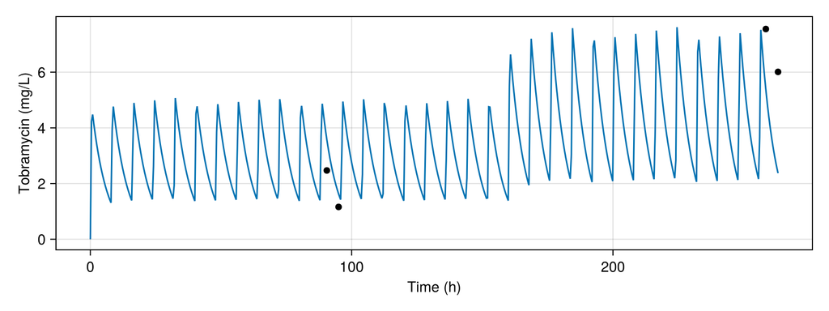

```julia
tobra_model = DCM(one_comp!, 1, Lux.Dense(1 => 2))
indv = tobramycin_pop[1]
grid = Float32.(range(0, maximum(get_t(indv)); length = 600))
sol = solve(tobra_model, indv, Float32[3.5, 20]; saveat = grid, dt = 0.01f0)    # CL = 3.5 L/h, V = 20 L

fig = Figure(size = (800, 300))
ax = Axis(fig[1, 1]; xlabel = "Time (h)", ylabel = "Tobramycin (mg/L)")
lines!(ax, grid, Array(sol)[1, :])
scatter!(ax, get_t(indv), get_y(indv); color = :black)
fig
```

Note

Data types must match: `Population` requires all individuals to have the same concrete type, which means the same number type, id type and callback type. Building every individual with the same helper function, as above, takes care of that.

## Checklist

- Dose and observation rows are separated (`MDV` or `EVID`), and observations that are `missing` are dropped.
- Times are in the same unit as the ODE's rate constants (hours throughout these tutorials).
- Doses are in the unit of the ODE state. Use `S1` or convert them yourself.
- Covariates are numeric. Categorical ones such as `SEX` need to be encoded first.
- Covariates are a fixed vector per individual. A different covariate per time point needs a `TimeVariableIndividual`, see Status and limitations.